# Final Project: USVI Mangrove Reproduction

Sarai Hutchinson

2024-12-05

# Objectives

The aim of this project is to use the GRROE Lab’s Master Intake Data for Red Mangroves to determine:

1. How the red mangrove collection sites have changed from 2021 to 2024?

2. Around what time of the year are the red mangroves reproducing most?

3. How has reproduction changed over time?

4. Map the Collection Sites of Red Mangroves

[figure not shown]

# Preparing Data

## Data Set-up

Load the necessary libraries anf functions:

1. tidyverse
2. dplyr
3. ggplot2
4. lubridate
5. writexl
6. split_collection_date_func.R

The first step is to import the CSV for the red mangrove intake data as of November 20th, 2024 and a CSV I made with the simplified collection sites coordinates.

## Data Cleaning

Then, begin performing QA/QC on the data by removing the spaces from the column headers.

It’s time to clean the data by formatting the dates to look the same for Collection Date and Date Planted. Create columns that separate the Collection Date column into Year, Month and Day.

```
##  [1] "Oasis Cove"        "Compass Pt."       "Compass Point"
##  [4] "CP"                "Marina"            "AL"
##  [7] "BB-HB"             "SR_HB"             "PB"
## [10] "SR"                "AB"                "OC"
## [13] "SR - MARINA"       "SALT RIVER MARINA" "ALTONA"
## [16] "SRBB"              "BB"                "MB"
## [19] "STEER ECOTOURS"    "MAGENS BAY"        "N/A"
## [22] NA                  "perseverance"      "Perseverance"
## [25] "Range Cay"         "STEER"             "Annaberg"
## [28] "Salt River"        "Preserverance"     "Brewers"
## [31] "Perserverance"     "Vessup"            "Mandahl"
```

```
##  [1] "Oasis Cove"       "Compass Point"    "Salt River"       "Altona Lagoon"
##  [5] "Perseverance Bay" "Annaberg Bay"     "Brewers Bay"      "Mandahl Bay"
##  [9] "STEER"            "Magens Bay"       "NA"               NA
## [13] "Range Cay"        "Vessup Bay"
```

By combining these different variations into a combined collection site, it makes it easier to visualize the data. I then have to further clean the data by removing any Collection Sites that were ‘NA’.

```
##  [1] "Oasis Cove"       "Compass Point"    "Salt River"       "Altona Lagoon"
##  [5] "Perseverance Bay" "Annaberg Bay"     "Brewers Bay"      "Mandahl Bay"
##  [9] "STEER"            "Magens Bay"       "Range Cay"        "Vessup Bay"
```

The next step is to print the unique collection dates to see what needs to be fixed.

```
##  [1] "4/16/2021"  "08-23-22"   "05-16-22"   "09/01/2022" "09/02/2022"
##  [6] "04-16-21"   "05/07/2021" "09/08/2022" "02-17-23"   "02-15-23"
## [11] "02-22-23"   "02/09/2023" "02-21-23"   "2/17/2023"  "2/18/2023"
## [16] "2/19/2023"  "2/20/2023"  "2/21/2023"  "2/22/2023"  "2/23/2023"
## [21] "2/24/2023"  "3/25/23"    "3/17/23"    "02/22/2023" "3/13/2023"
## [26] "3/17/2023"  "3//17/2023" "Jan-31"     NA           "06/11/2023"
## [31] "6/13/23"    "07/12/2023" "6/19/2023"  "7/24/2022"  "08/01/2023"
## [36] "8/14/2023"  "8/16/2023"  "9/15/2023"  "09/28/2023" "09/15/2023"
## [41] "9/28/2023"  "10/12/2023" "10/11/2023" "1/19/24"    "1/23/24"
## [46] "1/23/2024"  "1/29/2024"  "1/31/2024"  "1/31/24"    "02/09/2024"
## [51] "04/03/2024" "5/30/2024"  "6/28/2024"  "06/11/2024" "06/10/2024"
## [56] "07/05/2024" "8/14/2024"  "8/24/2024"  "06/12/2024" "21/02/2023"
## [61] "09/02/2023" "17/03/2023" "15/09/2023" "20/09/2023" "19/09/2002"
## [66] "9/19/23"    "9//19/23"   "10/20/23"   "09/02/2024" "9/13/2024"
## [71] "09/11/2024" "09/05/2024" "9/24/2024"  "10/26/2024" "10/25/2024"
## [76] "10/27/2024" "10/23/2024"
```

After looking at the CollectionDate column and finding a particularly early date, the next step is to change 19/09/2002 to 19/09/2023 after verifying the raw data and the fact that this collection only began in 2021.

I then made the Collection Date to be one format and checked to see if there were any dates that failed this section.

```
## [1] "Failed to parse the following dates:"
## [1] "Jan-31" NA
```

I created a function to help me split my newly created CollectionDateParsed column into Collection Year, Collection Month and Collection Day.

Now, I have the cleaned and filtered data that I exported and used to make my maps in Arc Gis Pro.

# Answering Questions

## Question 1

> How have the red mangrove collection sites have changed from 2021 to 2024?

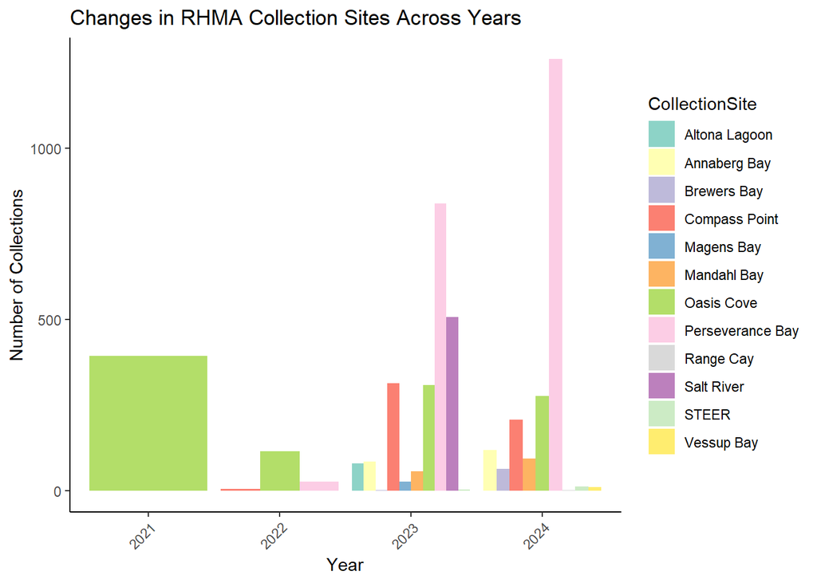

## Question 2

> Around what time of the year are the red mangroves reproducing most?

This question is difficult to answer with the current data. I would need data that has the number of collectors to have an effort factor, and we would have needed to have been going to collect mangroves at each site each month to determine whether more mangrove collection is because of effort or there actually being more mangroves at each site.

> The question I asked instead is what is the total number of red mangroves collected across all sites in a certain month

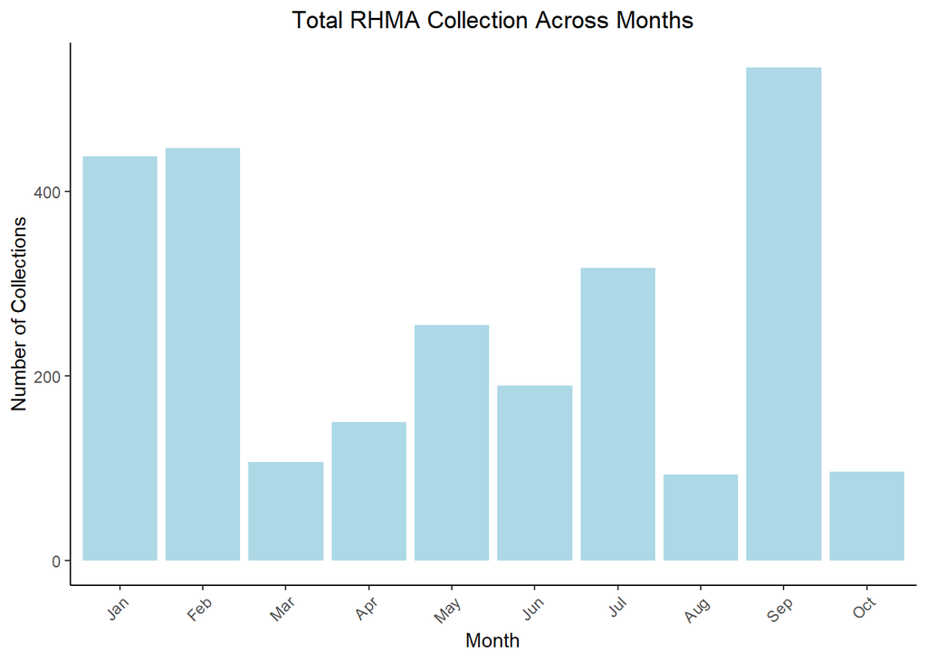

This bar graph shows that most mangroves were collected in September, followed by February and January. This corresponds with having more lab interns to help with collections.

```
## [1] "Month with Highest Red Mangrove Collections:"
```

```
## # A tibble: 1 × 2
##   CollectionMonth TotalCount
##   <chr>                <int>
## 1 Sep                   1107
```

```
## Year with Highest Red Mangrove Collections:
```

```
## # A tibble: 1 × 2
##   CollectionYear TotalCount
##   <chr>               <int>
## 1 2023                 2221
```

```
##
##  Month with Highest Collections for Each Year:
```

```
## # A tibble: 4 × 3
## # Groups:   CollectionYear [4]
##   CollectionYear CollectionMonth Count
##   <chr>          <chr>           <int>
## 1 2021           May               255
## 2 2022           Sep                59
## 3 2023           Sep               535
## 4 2024           Feb               447
```

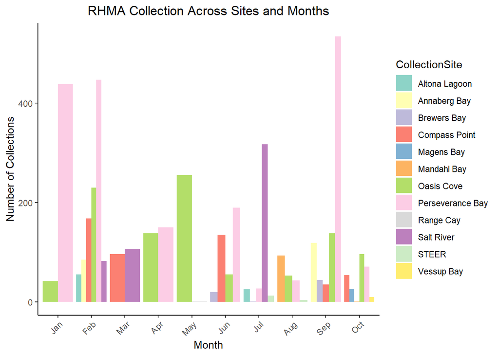

Perseverance Bay accounted for most of the RHMA collections in September, February and January.

## Question 3

> How has the number of red mangroves collected changed overtime?

I worked through a for loop to display the month that had the most RHMA collections in each year.

```
## Year: 2021, Month: May, Count: 255
## Year: 2022, Month: Sep, Count: 59
## Year: 2023, Month: Sep, Count: 535
## Year: 2024, Month: Feb, Count: 447
```

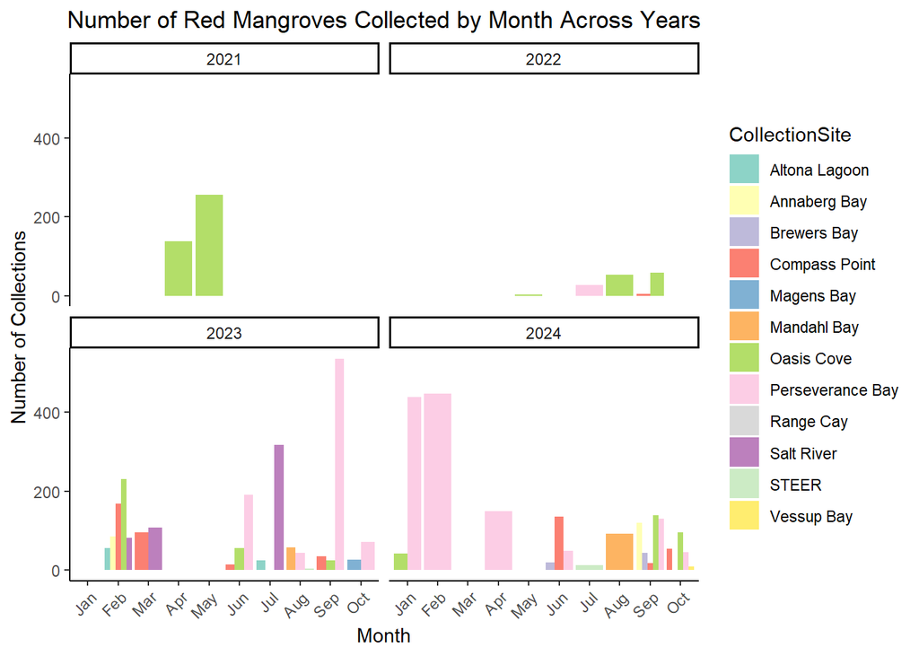

> How did total number of collection dates change over the years? Did we collect more or less?

Number of RHMA Collections by Year

| Collection Year | Number of Collections | Total Number of Mangroves Collected | Average Mangs Per Collection |
| --- | --- | --- | --- |
| 2021 | 2 | 393 | 393/2= ~197 |
| 2022 | 7 | 147 | 147/7 = 21 |
| 2023 | 43 | 2221 | 2221/43 = ~52 |
| 2024 | 26 | 2031 | 2031/26 = ~78 |

The next step is to show the unique collection dates of RHMA mangroves and how many were collected each time and at what sites.

```
## # A tibble: 78 × 5
##    CollectionYear CollectionMonth CollectionSite   CollectionDateParsed Count
##    <chr>          <chr>           <chr>            <dttm>               <int>
##  1 2021           04              Oasis Cove       2021-04-16 00:00:00    138
##  2 2021           05              Oasis Cove       2021-05-07 00:00:00    255
##  3 2022           05              Oasis Cove       2022-05-16 00:00:00      3
##  4 2022           07              Perseverance Bay 2022-07-24 00:00:00     27
##  5 2022           08              Oasis Cove       2022-08-23 00:00:00     53
##  6 2022           09              Compass Point    2022-09-02 00:00:00      5
##  7 2022           09              Oasis Cove       2022-09-01 00:00:00     29
##  8 2022           09              Oasis Cove       2022-09-02 00:00:00     17
##  9 2022           09              Oasis Cove       2022-09-08 00:00:00     13
## 10 2023           02              Altona Lagoon    2023-02-22 00:00:00     55
## # ℹ 68 more rows
```

Then, the average collections are displayed in a bar graph.

```
## # A tibble: 22 × 3
##    CollectionYear CollectionMonth AverageCollectionsPerMonth
##    <chr>          <chr>                                <dbl>
##  1 2021           04                                   138
##  2 2021           05                                   255
##  3 2022           05                                     3
##  4 2022           07                                    27
##  5 2022           08                                    53
##  6 2022           09                                    16
##  7 2023           02                                    32.6
##  8 2023           03                                    40.6
##  9 2023           06                                    65
## 10 2023           07                                   114.
## # ℹ 12 more rows
```

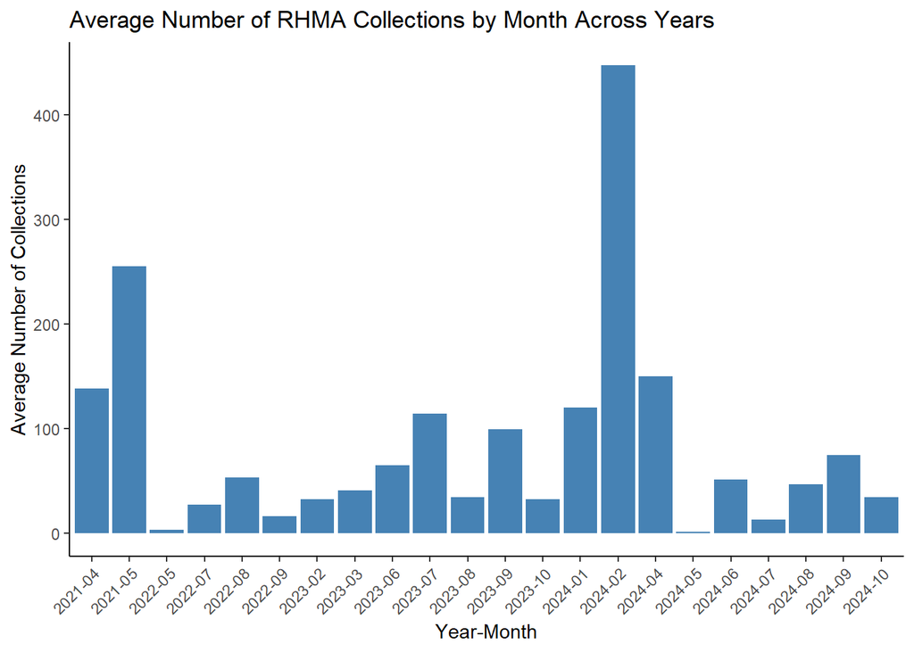

## Question 4

> What is the number of total propagules divided by the number of unique collection dates across all months for each site?

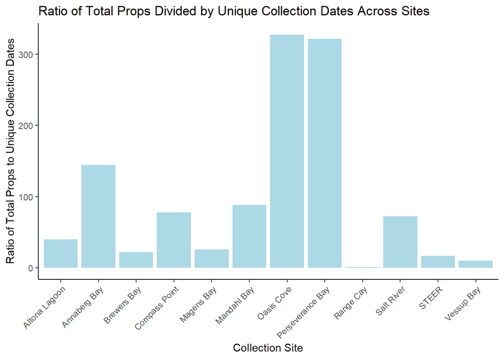

I then wanted to graph the same data but have it split into years.

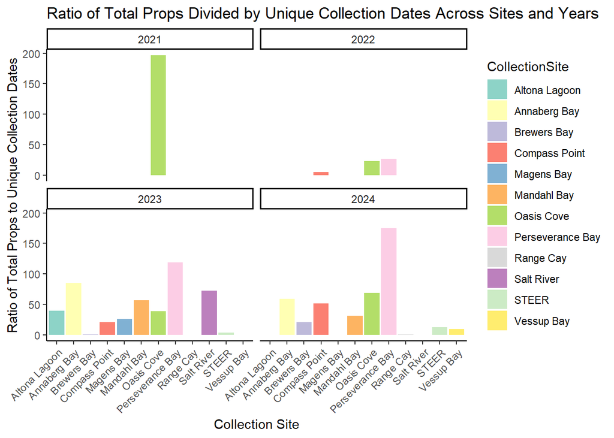

# Map of Collection Sites

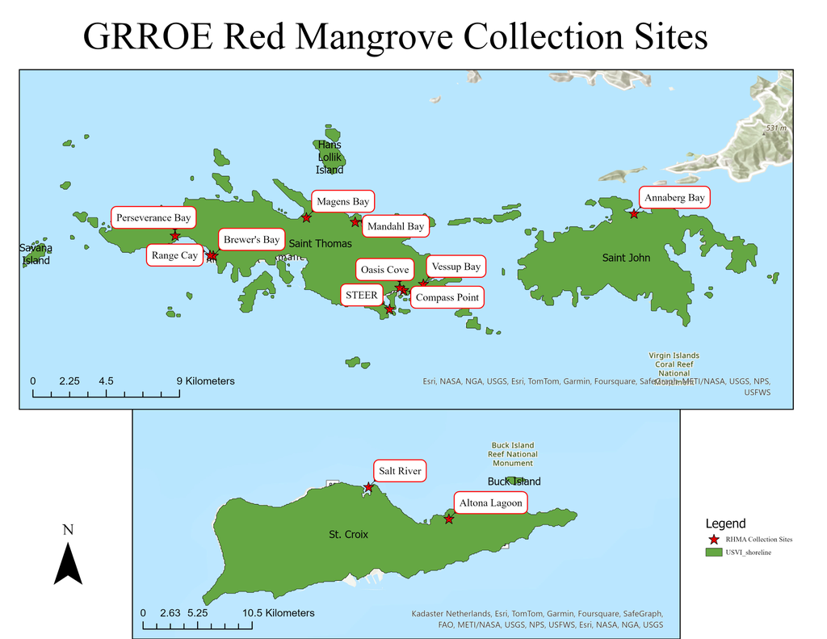

GRROE Lab Red Mangrove (RHMA) Collection Sites

## Future Arc GIS Pro Steps

> To create a map of red mangrove species proportion: pie chart with proportions for each site, and time of year where the pie is months. I’d then filter by year and graph by month and site.

I struggled to make charts in Arc GIS Pro but have the data I’d need to reopen this project and complete it.